# Poverty Rates and Inequality in Latin America

Authors: Ana Baide and Carlos Gottret

# Description

In Latin America, the intricate relationship between economics, wealth distribution, and poverty reduction plays a pivotal role in shaping the region's socio-economic landscape. As one of the most economically diverse regions in the world, Latin America faces unique challenges and opportunities in achieving sustainable development and reducing poverty.

Latin America's economic landscape exhibits a wide spectrum, ranging from high-income countries to those grappling with socio-economic disparities and high poverty rates. To understand better Latin America's economy and what factors affect it more harshly than other regions we will be looking at direct data from Latin American countries and the rest of the world. Through different exploratory analysis and data visualizations we will show how inequality and distribution of wealth directly correlate with poverty.

## Importance

There is a huge importance in stuying Latin America countries (LAC). LAC contains a large population, is rich in natural resources and has extensive trade parnerships. In general economic growth serves as a catalyst for poverty reduction, job creation, and improved living standards. When coupled with equitable wealth distribution, it can drive social mobility, empower marginalized communities, and enhance overall well-being. Conversely, persistently unequal wealth distribution can hinder sustainable development, perpetuate social divisions, and impede progress towards poverty alleviation. Looking at both of those factors not only affect this region, but the entire world.

## Motivation and Relevance

Through this analysis, we can uncover patterns, trends, and drivers that shape the region's economic landscape. These insights can inform evidence-based policy decisions, foster innovative approaches to wealth redistribution, and guide strategies that address systemic challenges faced by Latin America.

# Data Collection

The World Bank, a prominent international financial institution, has established a well-earned reputation for providing credible and reliable data that is widely recognized and respected across the globe. As a trusted source of information, the World Bank adheres to rigorous data collection methodologies and upholds strict quality standards, ensuring the accuracy and integrity of its datasets.

One key aspect that contributes to the credibility of the World Bank is its commitment to transparency and accountability. The institution follows robust data collection protocols, employing rigorous validation processes to ensure the accuracy and consistency of the data. The World Bank operates with a non-biased approach, emphasizing objectivity and impartiality in data collection and analysis. This commitment to neutrality allows policymakers, researchers, and stakeholders to rely on the World Bank's data with confidence, knowing that it is free from undue influence or bias. These datasets cover a wide range of socio-economic indicators, enabling comprehensive analyses and facilitating evidence-based decision-making.

[Poverty Database](https://data.worldbank.org/topic/poverty)  
[Gini Inequality Database](https://data.worldbank.org/indicator/SI.POV.GINI)

## Import Statements

```python
import pandas as pd
import numpy as np
import matplotlib.pyplot as plt
import seaborn as sns
from scipy.stats import ttest_ind
from scipy.stats import pearsonr
import statsmodels.api as sm
from sklearn.linear_model import LinearRegression
```

## Getting the Data

The raw data from the World Bank was very extensive. For the purposes of our data analysis we removed certain columns; the following columns held no significant relevance to our analysis:

- region_code
- survey_acronym
- survey_coverage
- survey_year
- survey_comparability
- comparable_spell
- watts
- mld
- polarization
- is_interpolated
- distribution_type
- estimation_type

We found that the columns above gave unnecessary data for our specific analysis. For example, 'region_code' and 'survey_acronym' may represent codes or acronyms that are not directly related to the variables we are investigating.

By dropping these columns, we are streamlining the dataset to focus on the key variables of interest, such as 'country_name', 'reporting_year', 'reporting_gdp', 'headcount', 'poverty_gap', and 'gini', which are directly relevant to understanding wealth distribution and poverty levels across countries and years.

```python
# Getting the data
data = pd.read_csv('pip.csv')

# Dropping irrelevant columns
columns_to_drop = ['region_code', 'survey_acronym', 'survey_coverage', 'survey_year', 'survey_comparability', 'comparable_spell', 'watts', 'mld', 'polarization','reporting_pce', 'is_interpolated', 'distribution_type', 'estimation_type']
data = data.drop(columns_to_drop, axis=1)
```

## Data Processing

The World Bank divides countries into regions to facilitate the analysis of development indicators across geographical areas. As a result, the dataset has seven unique regions: Sub-Saharan Africa, Europe & Central Asia, High-Income Countries, Latin America & Caribbean, South Asia, East Asia & Pacific, and Middle East & North Africa. Classifying countries into regions allows a more focused examination of regional trends, challenges, and opportunities.

Within the dataset is a specific classification called "Other High Income Countries," which includes countries classified as high-income by the World Bank. The World Bank determines a country's income level based on its Gross National Income (GNI) per capita, which represents the total income of a country's residents. A high-income country is typically characterized by a high level of economic development, a strong and diverse economy, a high standard of living, and well-established infrastructure and institutions. The 2020 GNI per capita threshold for high-income is greater than $12,535.

Including the "Other High Income Countries" classification may lead to some confusion. The regions contain only countries that do not surpass the threshold of a GNI per capita of $12,535. These countries are also known as "developing countries" or "borrowing countries".

```python
# Number of regions
num_regions = data['region_name'].nunique()
print(f"There are {num_regions} unique values of region_name in the data.")

# Regions names
unique_regions = data['region_name'].unique()
print("\nThe unique values of region_name are:")
for region in unique_regions:
    print(region)
```

```
There are 7 unique values of region_name in the data.

The unique values of region_name are:
Sub-Saharan Africa
Europe & Central Asia
Other High Income Countries
Latin America & Caribbean
South Asia
East Asia & Pacific
Middle East & North Africa
```

## Dealing with Missing Data

This dataset had some missing data. Several columns had missing data, including 'median', 'gini', 'decile1' to 'decile10', and 'ppp'. However, the missing data is relatively small. Only ~0.358% of the data was missing from the data set, accounting for a tiny portion of the overall dataset.

Given the small percentage of missing data, it is unlikely to significantly impact the overall results or conclusions drawn from the analysis. The remaining data points still provide substantial information and can yield valuable insights into the patterns and trends being examined.

Though in some data analyses, it is necessary to handle missing data, in this case, the small percentage of missing data suggests that it is unlikely to substantially affect the overall findings or interpretations derived from the dataset.

```python
print(data.isna().sum())

missing_percentage = data.isna().sum().sum() / (len(data) * (len(data.columns) - 1))
print("\nPercent of missing data: " + str(round(missing_percentage * 100, 3)))
```

```
region_name          0
country_name         0
country_code         0
reporting_year       0
reporting_level      0
welfare_type         0
poverty_line         0
headcount            0
poverty_gap          0
poverty_severity     0
mean                 0
median              68
gini                 6
decile1              8
decile2              8
decile3              8
decile4              8
decile5              8
decile6              8
decile7              8
decile8              8
decile9              8
decile10             8
cpi                  0
ppp                 62
reporting_pop        0
reporting_gdp        0
dtype: int64

Percent of missing data: 0.358
```

The columns that will be analyzed have the following definitions:

- region_name: The name of the region where the country is located (e.g., Latin America and the Caribbean).
- region_code: A numerical code assigned to the region where the country is located.
- country_name: The name of the country.
- country_code: A three-letter code assigned to the country.
- reporting_year: The year the poverty and inequality data was collected and reported.
- reporting_level: The level of geographic coverage for the data (e.g., national, urban, rural).
- survey_acronym: An acronym for the survey used to collect the data.
- survey_coverage: The percentage of the population covered by the survey.
- survey_year: The year the survey was conducted.
- welfare_type: The welfare measure used to calculate poverty (e.g., consumption, income).
- survey_comparability: A measure of the comparability of the survey to other surveys in the dataset.
- comparable_spell: The number of years of data that are comparable across surveys.
- poverty_line: The poverty line used to calculate poverty rates (in purchasing power parity (PPP) terms).
- headcount: The percentage of the population living below the poverty line.
- poverty_gap: The percentage by which the poverty line falls short of the mean welfare level of the poor population.
- poverty_severity: The squared poverty gap, which measures the extent to which the poor are below the poverty line.
- watts: The poverty gap squared divided by the poverty line, which measures the depth of poverty.
- mean: The mean welfare level in PPP terms.
- median: The median welfare level in PPP terms.
- mld: The minimum living level, which is the welfare level of the person at the poverty line.
- gini: The Gini coefficient measures the inequality level in the distribution of welfare levels.
- polarization: The polarization index measures the extent to which welfare levels are polarized around the poverty line.
- decile1 to decile10: The percentage of total welfare held by each decile of the population, where decile1 is the poorest 10%, and decile10 is the richest 10%.
- cpi: The consumer price index.
- ppp: The PPP conversion factor.
- reporting_pop: The reported population of the country.
- reporting_gdp: The reported GDP of the country.
- is_interpolated: A flag indicating whether the data has been interpolated.
- distribution_type: The type of distribution (e.g., log-normal, Weibull) used to fit the data.
- estimation_type: The type of estimation (e.g., maximum likelihood, Bayesian) used to estimate the parameters of the distribution.

These definitions were taken from articles and research done by the World Bank. A glossary of definitions for terms often used at the World Bank can be found at https://databank.worldbank.org/metadataglossary/all/series

Below is what our table currently looks like. Leaving it as it is would make analyzing difficult; we need to parse the data into manageable groups.

```python
data
```

|  | region_name | country_name | country_code | reporting_year | reporting_level | welfare_type | poverty_line | headcount | poverty_gap | poverty_severity | ... | decile5 | decile6 | decile7 | decile8 | decile9 | decile10 | cpi | ppp | reporting_pop | reporting_gdp |
| --- | --- | --- | --- | --- | --- | --- | --- | --- | --- | --- | --- | --- | --- | --- | --- | --- | --- | --- | --- | --- | --- |
| 0 | Sub-Saharan Africa | Angola | AGO | 2000 | national | consumption | 3.75 | 0.407261 | 0.183455 | 0.112344 | ... | 0.056628 | 0.070488 | 0.088085 | 0.113495 | 0.158687 | 0.402455 | 0.014200 | 107.269989 | 16394062 | 1832.514102 |
| 1 | Sub-Saharan Africa | Angola | AGO | 2008 | national | consumption | 3.75 | 0.390215 | 0.138699 | 0.066854 | ... | 0.065426 | 0.079204 | 0.096514 | 0.122917 | 0.162333 | 0.323117 | 0.303449 | 107.269989 | 21691522 | 3048.594002 |
| 2 | Sub-Saharan Africa | Angola | AGO | 2018 | national | consumption | 3.75 | 0.543459 | 0.253090 | 0.150827 | ... | 0.055843 | 0.069814 | 0.088688 | 0.115687 | 0.159390 | 0.396244 | 1.231024 | 107.269989 | 31273533 | 2677.177816 |
| 3 | Europe & Central Asia | Albania | ALB | 1996 | national | consumption | 3.75 | 0.105004 | 0.018309 | 0.005290 | ... | 0.083797 | 0.093549 | 0.108231 | 0.124739 | 0.148995 | 0.212156 | 0.399635 | 50.357372 | 3168033 | 1633.551572 |
| 4 | Europe & Central Asia | Albania | ALB | 2002 | national | consumption | 3.75 | 0.127726 | 0.025329 | 0.007934 | ... | 0.076531 | 0.088395 | 0.102286 | 0.119844 | 0.149251 | 0.254356 | 0.701637 | 50.357372 | 3051010 | 2247.497491 |
| ... | ... | ... | ... | ... | ... | ... | ... | ... | ... | ... | ... | ... | ... | ... | ... | ... | ... | ... | ... | ... | ... |
| 2315 | Sub-Saharan Africa | Zambia | ZMB | 2010 | national | consumption | 3.75 | 0.835266 | 0.531573 | 0.380711 | ... | 0.046619 | 0.058262 | 0.075170 | 0.103729 | 0.158176 | 0.452326 | 0.552642 | 4.223818 | 13792086 | 1198.304817 |
| 2316 | Sub-Saharan Africa | Zambia | ZMB | 2015 | national | consumption | 3.75 | 0.783390 | 0.489498 | 0.353666 | ... | 0.045549 | 0.060149 | 0.081183 | 0.111607 | 0.168868 | 0.443809 | 0.796036 | 4.223818 | 16248230 | 1307.909649 |
| 2317 | Sub-Saharan Africa | Zimbabwe | ZWE | 2011 | national | consumption | 3.75 | 0.493062 | 0.184566 | 0.088669 | ... | 0.063459 | 0.076563 | 0.093228 | 0.116885 | 0.158343 | 0.338301 | 0.980643 | 0.485028 | 13025785 | 1239.241794 |
| 2318 | Sub-Saharan Africa | Zimbabwe | ZWE | 2017 | national | consumption | 3.75 | 0.629692 | 0.268657 | 0.140429 | ... | 0.059552 | 0.072160 | 0.089793 | 0.116523 | 0.163039 | 0.348078 | 1.000000 | 0.485028 | 14751101 | 1421.240770 |
| 2319 | Sub-Saharan Africa | Zimbabwe | ZWE | 2019 | national | consumption | 3.75 | 0.655456 | 0.308508 | 0.176946 | ... | NaN | NaN | NaN | NaN | NaN | NaN | 1.000000 | 0.485028 | 15354608 | 1342.989587 |

2320 rows × 27 columns

## Data Parsing and Grouping

We need to group our data into distinct regions to create the appropriate graphs. Now that we have these regions, we can extrapolate the number of countries in each classification to understand data distribution better.

```python
# Dividing data by regions and getting the amount of countries per region
sub_saharan_data = data[data['region_name'] == 'Sub-Saharan Africa']
countries = sub_saharan_data['country_name'].nunique()
print(f"There are {countries} countries in Sub-Saharan Africa.")

europe_asia_data = data[data['region_name'] == 'Europe & Central Asia']
countries = europe_asia_data['country_name'].nunique()
print(f"There are {countries} countries in Europe & Central Asia.")

high_income_data = data[data['region_name'] == 'Other High Income Countries']
countries = high_income_data['country_name'].nunique()
print(f"There are {countries} countries in Other High Income Countries.")

latin_america_data = data[data['region_name'] == 'Latin America & Caribbean']
countries = latin_america_data['country_name'].nunique()
print(f"There are {countries} countries in Latin America & Caribbean.")

south_asia_data = data[data['region_name'] == 'South Asia']
countries = south_asia_data['country_name'].nunique()
print(f"There are {countries} countries in South Asia.")

east_asia_data = data[data['region_name'] == 'East Asia & Pacific']
countries = east_asia_data['country_name'].nunique()
print(f"There are {countries} countries in East Asia & Pacific.")

middle_north_data = data[data['region_name'] == 'Middle East & North Africa']
countries = middle_north_data['country_name'].nunique()
print(f"There are {countries} countries in Middle East & North Africa.")
```

```
There are 45 countries in Sub-Saharan Africa.
There are 30 countries in Europe & Central Asia.
There are 28 countries in Other High Income Countries.
There are 25 countries in Latin America & Caribbean.
There are 7 countries in South Asia.
There are 21 countries in East Asia & Pacific.
There are 12 countries in Middle East & North Africa.
```

# Exploratory Analysis and Data Visualization

Graphing the data is vital to the exploratory analysis and data visualization phase. This step is essential before hypothesis testing.

Graphing facilitates visually exploring patterns, distributions, potential variables of interest, and relationships within the dataset. Furthermore, graphing provides an initial understanding of the variables and helps identify outliers or unusual observations.

In the specific context of this dataset, which includes information on wealth distribution, poverty measures, and economic indicators across different regions, we can expect to see various patterns and relationships. Some things we could expect to see from this dataset include:

1. Wealth Distribution Patterns: We can visualize the wealth distribution across different deciles and regions, examining the proportion of wealth held by each segment of the population.
2. Poverty Measures: We can explore the headcount, poverty gap, and poverty severity measures across regions and countries. The visualization helps put into context the severity of poverty in some of the regions.
3. Economic Indicators: We can analyze the relationship between economic indicators such as GDP and poverty.
4. Regional Comparisons: We can compare and contrast the wealth distribution and poverty measures across different regions, identifying disparities and differences in socioeconomic conditions.

Overall, graphing the data in the exploratory analysis phase helps us better understand the dataset, identify initial patterns and relationships, and form hypotheses for further analysis and hypothesis testing. In addition, it provides a visual foundation for exploring the data and generating insights to drive subsequent statistical analyses.

## Initial Observations: Poverty(Headcount), GDP, and Gini Coefficient across Regions

### Headcount Ratio by Region Comparison

Headcount refers to the percentage or proportion of the population below the poverty line. It is a commonly used measure in poverty analysis and provides valuable insights into the extent of poverty within a country or region. A lower headcount ratio is generally considered good because it indicates that a smaller proportion of the population lives below the poverty line.

We graphed the variable 'Headcount' first because:

1. Simple and Understandable: Headcount is a straightforward and intuitive measure of poverty.
2. Captures the Extent of Poverty: Headcount provides a broad overview of the magnitude of poverty within a country.
3. Regional and Global Comparisons: Graphing the headcount across countries enables us to compare poverty levels across regions or countries.

By graphing the headcount of each country, we can visually identify countries with higher poverty rates, observe variations in poverty levels across regions, and uncover relationships between poverty and other factors. It provides a starting point for deeper analysis and can guide further exploration into poverty's underlying factors and dynamics.

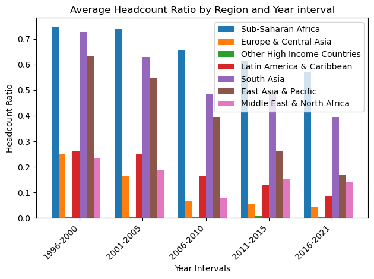

```python
# Define the intervals
intervals = [(1996, 2000), (2001, 2005), (2006, 2010), (2011, 2015), (2016, 2021)]

# Create a dictionary to store the data for each region
region_data = {}
for region in unique_regions:
    region_data[region] = []

# Fill the dictionary with the data for each region and interval
for interval in intervals:
    start_year, end_year = interval

    # Select the relevant reporting_year
    interval_data = data[(data['reporting_year'] >= start_year) & (data['reporting_year'] <= end_year)]
    for region in region_data.keys():
        # Put the correct placement
        region_interval_data = interval_data[interval_data['region_name'] == region]
        headcount_mean = region_interval_data['headcount'].mean()
        region_data[region].append(headcount_mean)

# Graph settings
x = [f"{interval[0]}-{interval[1]}" for interval in intervals]

# Needed for the space
width = 1 / (len(region_data) + 2)
offset = -0.5 + width

for i, (region, region_values) in enumerate(region_data.items()):
    x_pos = [j + offset + i * width for j in range(len(region_values))]
    plt.bar(x_pos, region_values, width, label=region)

# Rotating axes for better readability
plt.xticks(range(len(x)), x, rotation=45, ha="right")

# Plotting axes
plt.xlabel('Year Intervals')
plt.ylabel('Headcount Ratio')

# Legend and title
plt.legend()
plt.title('Average Headcount Ratio by Region and Year interval')

# Padding
plt.tight_layout()

#Print graph
plt.show()
```

### Gross Domestic Product by Region Comparison

GDP (Gross Domestic Product) is a commonly used measure of the development of a country. It represents the total value of all goods and services produced within a country's borders in a specific period.

Following headcount, we graphed GDP because having a reliable and published variable to compare development allows comparative analysis.

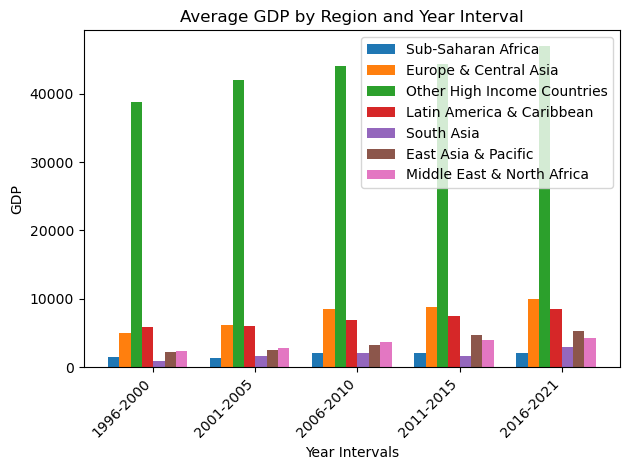

```python
# Making the dictionary to store the data for each region empty again
region_data = {}
for region in unique_regions:
    region_data[region] = []

# Fill the dictionary with the data for each region and interval
for interval in intervals:
    start_year, end_year = interval

    # Select the relevant reporting_year
    interval_data = data[(data['reporting_year'] >= start_year) & (data['reporting_year'] <= end_year)]
    for region in region_data.keys():
        # Put the correct placement
        region_interval_data = interval_data[interval_data['region_name'] == region]
        gdp_mean = region_interval_data['reporting_gdp'].mean()
        region_data[region].append(gdp_mean)

# Graph settings
x = [f"{interval[0]}-{interval[1]}" for interval in intervals]

# Needed for the space
width = 1 / (len(region_data) + 2)
offset = -0.5 + width

for i, (region, region_values) in enumerate(region_data.items()):
    x_pos = [j + offset + i * width for j in range(len(region_values))]
    plt.bar(x_pos, region_values, width, label=region)

# Rotating axes for better readability
plt.xticks(range(len(x)), x, rotation=45, ha="right")

# Plotting axes
plt.xlabel('Year Intervals')
plt.ylabel('GDP')

# Legend and title
plt.legend()
plt.title('Average GDP by Region and Year Interval')

# Padding
plt.tight_layout()

# Graph
plt.show()
```

### Gini Coefficient by Region Comparison

The Gini coefficient measures income or wealth inequality within a region or country. It quantifies the extent to which the distribution of income or wealth deviates from a perfectly equal distribution.

Here's why the Gini coefficient would be a good variable to graph:

1. Inequality Measure: The Gini coefficient is a widely used measure of inequality.
2. Economic Implications: Income or wealth inequality has significant economic implications. Graphing the Gini coefficient helps us understand the extent of inequality within a region or country and its potential consequences on economic outcomes.

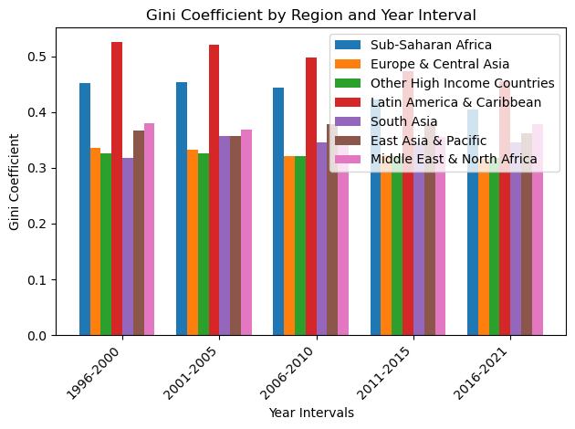

```python
# Making the dictionary to store the data for each region empty again
region_data = {}
for region in unique_regions:
    region_data[region] = []

# Fill the dictionary with the data for each region and interval
for interval in intervals:
    start_year, end_year = interval
    interval_data = data[(data['reporting_year'] >= start_year) & (data['reporting_year'] <= end_year)]
    for region in region_data.keys():
        region_interval_data = interval_data[interval_data['region_name'] == region]
        gini_mean = region_interval_data['gini'].mean()
        region_data[region].append(gini_mean)

# Graph settings
x = [f"{interval[0]}-{interval[1]}" for interval in intervals]

# Needed for the space
width = 1 / (len(region_data) + 2)
offset = -0.5 + width

for i, (region, region_values) in enumerate(region_data.items()):
    x_pos = [j + offset + i * width for j in range(len(region_values))]
    plt.bar(x_pos, region_values, width, label=region)

# Rotating axes for better readability
plt.xticks(range(len(x)), x, rotation=45, ha="right")

# Plotting axes
plt.xlabel('Year Intervals')
plt.ylabel('Gini Coefficient')

# Legend and title
plt.legend()
plt.title('Gini Coefficient by Region and Year Interval')

# Padding and plot
plt.tight_layout()
plt.show()
```

Based on the data observations:

Headcount:

GDP:

- As expected, high-income countries exhibit higher GDP values compared to other regions.
- An interesting observation is that Europe and Central Asia region shows relatively similar GDP levels to LAC.
- LAC has higher GDP values compared to all other regions except high-income countries and Europe and Central Asia.

Gini:

- LAC stands out with higher Gini coefficients compared to other regions, indicating greater income inequality.

## Exploring Relationships: Scatter Plots of Poverty-GDP and Poverty-Gini Coefficient

### Poverty VS GDP Relationship

We will create a scatter plot of the poverty gap and GDP to explore the relationship between these variables and gain insights into the economic conditions and poverty levels across different regions.

This plot helps us understand how changes in GDP, often considered an indicator of a country's economic well-being, are related to variations in the poverty gap.

For example, we can examine that higher GDP values correspond to lower poverty gaps in regard to High Income countries, indicating a positive relationship between economic growth and poverty reduction. The issue with this is that we can identify these as outliers or region that deviate from the expected pattern.

The scatter plot allows for a comprehensive view of the data, enabling comparisons across regions and identifying any significant disparities in poverty levels and economic performance.

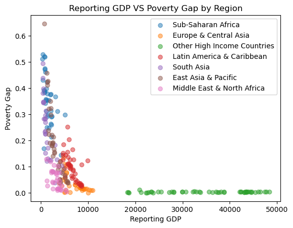

```python
# Group data by year for each region
sub_saharan_data_yearly = sub_saharan_data.groupby('reporting_year').mean(numeric_only=True)
europe_asia_data_yearly = europe_asia_data.groupby('reporting_year').mean(numeric_only=True)
high_income_data_yearly = high_income_data.groupby('reporting_year').mean(numeric_only=True)
latin_america_data_yearly = latin_america_data.groupby('reporting_year').mean(numeric_only=True)
south_asia_data_yearly = south_asia_data.groupby('reporting_year').mean(numeric_only=True)
east_asia_data_yearly = east_asia_data.groupby('reporting_year').mean(numeric_only=True)
middle_north_data_yearly = middle_north_data.groupby('reporting_year').mean(numeric_only=True)

# Create scatter plot for each region
plt.scatter(sub_saharan_data_yearly['reporting_gdp'], sub_saharan_data_yearly['poverty_gap'], alpha=0.5, label='Sub-Saharan Africa')
plt.scatter(europe_asia_data_yearly['reporting_gdp'], europe_asia_data_yearly['poverty_gap'], alpha=0.5, label='Europe & Central Asia')
plt.scatter(high_income_data_yearly['reporting_gdp'], high_income_data_yearly['poverty_gap'], alpha=0.5, label='Other High Income Countries')
plt.scatter(latin_america_data_yearly['reporting_gdp'], latin_america_data_yearly['poverty_gap'], alpha=0.5, label='Latin America & Caribbean')
plt.scatter(south_asia_data_yearly['reporting_gdp'], south_asia_data_yearly['poverty_gap'], alpha=0.5, label='South Asia')
plt.scatter(east_asia_data_yearly['reporting_gdp'], east_asia_data_yearly['poverty_gap'], alpha=0.5, label='East Asia & Pacific')
plt.scatter(middle_north_data_yearly['reporting_gdp'], middle_north_data_yearly['poverty_gap'], alpha=0.5, label='Middle East & North Africa')

plt.xlabel('Reporting GDP')
plt.ylabel('Poverty Gap')
plt.title('Reporting GDP VS Poverty Gap by Region')

plt.legend()
plt.show()
```

Now we create a scatter plot of the Gini coefficient and GDP to examine the relationship between income inequality and economic prosperity across different regions. By plotting the Gini coefficient against GDP, we can gain insights into how changes in economic development relate to income inequality.

Regarding the other regions, it is currently unclear if looking at this data alone might provide any information concerning the existing inequality. In this case, we must evaluate this data more deeply through linear models in the next section.

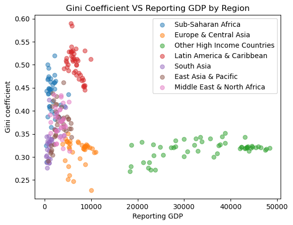

```python
# Create scatter plot for each region
plt.scatter(sub_saharan_data_yearly['reporting_gdp'], sub_saharan_data_yearly['gini'], alpha=0.5, label='Sub-Saharan Africa')
plt.scatter(europe_asia_data_yearly['reporting_gdp'], europe_asia_data_yearly['gini'], alpha=0.5, label='Europe & Central Asia')
plt.scatter(high_income_data_yearly['reporting_gdp'], high_income_data_yearly['gini'], alpha=0.5, label='Other High Income Countries')
plt.scatter(latin_america_data_yearly['reporting_gdp'], latin_america_data_yearly['gini'], alpha=0.5, label='Latin America & Caribbean')
plt.scatter(south_asia_data_yearly['reporting_gdp'], south_asia_data_yearly['gini'], alpha=0.5, label='South Asia')
plt.scatter(east_asia_data_yearly['reporting_gdp'], east_asia_data_yearly['gini'], alpha=0.5, label='East Asia & Pacific')
plt.scatter(middle_north_data_yearly['reporting_gdp'], middle_north_data_yearly['gini'], alpha=0.5, label='Middle East & North Africa')

# Labels and title
plt.xlabel('Reporting GDP')
plt.ylabel('Gini coefficient')
plt.title('Gini Coefficient VS Reporting GDP by Region')
plt.legend()

# Print data
plt.show()
```

### Poverty VS Gini Relationship

Finally, let's create a scatter plot of the poverty gap and the Gini coefficient to examine the relationship between income inequality and poverty levels within different regions. This plot allows us to visually analyze the concentration of poverty in the various areas of the Gini coefficient. Moreover, observing the scatter plot can identify a clear correlation between low poverty rates and Gini coefficients.

In particular, when analyzing Europe and Central Asia, and High-Income Countries, we can observe a distinct pattern indicating a strong relationship between income inequality and poverty levels. However, to gain a comprehensive understanding, it is necessary to explore further the other regions using linear regression models, as their relationship may be less apparent.

By conducting linear regression analyses on these regions, we can quantitatively assess the strength and direction of the relationship between the poverty gap and the Gini coefficient. This will give us more insights into the complex dynamics between income inequality and poverty across different regions.

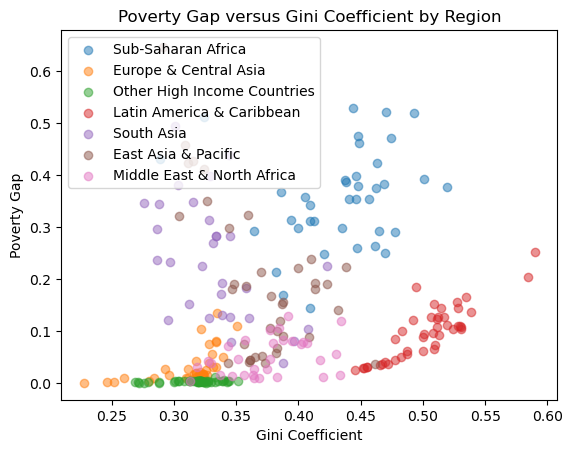

```python
# Create scatter plot for Gini Coefficient and Poverty Gap by region
plt.scatter(sub_saharan_data_yearly['gini'], sub_saharan_data_yearly['poverty_gap'], alpha=0.5, label='Sub-Saharan Africa')
plt.scatter(europe_asia_data_yearly['gini'], europe_asia_data_yearly['poverty_gap'], alpha=0.5, label='Europe & Central Asia')
plt.scatter(high_income_data_yearly['gini'], high_income_data_yearly['poverty_gap'], alpha=0.5, label='Other High Income Countries')
plt.scatter(latin_america_data_yearly['gini'], latin_america_data_yearly['poverty_gap'], alpha=0.5, label='Latin America & Caribbean')
plt.scatter(south_asia_data_yearly['gini'], south_asia_data_yearly['poverty_gap'], alpha=0.5, label='South Asia')
plt.scatter(east_asia_data_yearly['gini'], east_asia_data_yearly['poverty_gap'], alpha=0.5, label='East Asia & Pacific')
plt.scatter(middle_north_data_yearly['gini'], middle_north_data_yearly['poverty_gap'], alpha=0.5, label='Middle East & North Africa')

# Labels and title
plt.xlabel('Gini Coefficient')
plt.ylabel('Poverty Gap')
plt.title('Poverty Gap versus Gini Coefficient by Region')

# Print data
plt.legend()
plt.show()
```

In conclusion, the scatter plots examining the relationships between the poverty gap and GDP, the Gini coefficient and GDP, and the poverty gap and Gini coefficient have provided valuable insights into the interplay between income inequality and poverty levels across different regions. In addition, we have observed distinct patterns and variations among regions, highlighting the importance of considering income inequality and poverty in understanding economic well-being. The next step in our analysis is to perform linear regression and hypothesis testing to determine the strength of these relationships and assess their statistical significance. By quantifying the relationships and evaluating their relevance, we can draw more conclusive insights and explore the elasticity values to understand the potential impact of changes in GDP on poverty and income inequality.

# Linear Regression and Hypothesis Testing: Exploring the Strength and Significance of Relationships

In this section, we aim to investigate the relationships observed in the scatter plots and assess their strength and statistical significance through linear regression and hypothesis testing. By fitting regression models to the data, we can quantify the relationships between variables and determine the extent to which changes in one variable can explain or predict changes in another. Additionally, hypothesis testing will allow us to assess whether the observed relationships are statistically significant, providing further evidence to support our conclusions.

## Linear Regression Model for Poverty VS GDP

For this particular pair of data, we will be looking at poverty as a funtion of GDP, with the hypothesis that as the GDP increase the poverty should linearly decrease. In particular we will be finding 3 different values for this equation:

$$\text{Poverty Gap} = \alpha + \beta \times \text{GDP}$$

$$\text{Change in GDP} = \frac{1}{\beta} \times (-1)$$

### Plotting the Entire Data

In this linear regression model, we are taking all our data to get a regression line that helps us predict and see the relationship between these two variables. As expected, the resulting values of this model are only partially valid for our primary focus (LAC) since including High-Income countries shift the data due to their high GDP values and knowingly low levels of poverty.

```
Poverty VS GDP Results
Slope: -3.078104919854103e-06
Intercept: 0.13270238434314968
Change in GDP required to decrease the poverty gap by 1%: 324875.21576990245
```

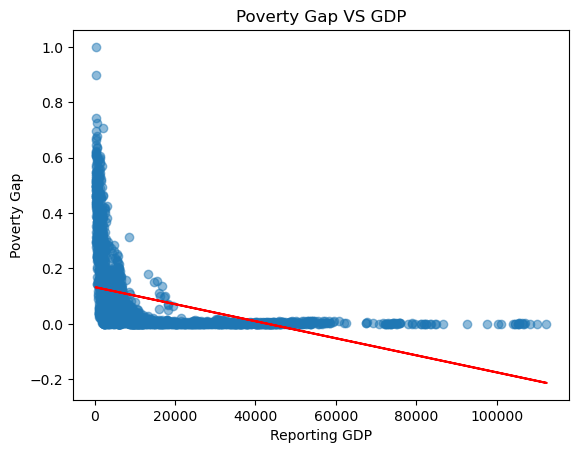

```python
# Prepare the data
X = data['reporting_gdp'].values.reshape(-1, 1)
y = data['poverty_gap'].values

# Create and fit the linear regression model
reg = LinearRegression()
reg.fit(X, y)

# Slope and intercept
slope = reg.coef_[0]
intercept = reg.intercept_

print('Poverty VS GDP Results')
print('Slope:', slope)
print('Intercept:', intercept)

change_in_gdp = (1 / slope) * (-1)
print("Change in GDP required to decrease the poverty gap by 1%:", change_in_gdp)

# Scatter plot
plt.scatter(data['reporting_gdp'], data['poverty_gap'], alpha=0.5)
plt.xlabel('Reporting GDP')
plt.ylabel('Poverty Gap')
plt.title('Poverty Gap VS GDP')

# Regression line
x_values = data['reporting_gdp']
y_values = slope * x_values + intercept
plt.plot(x_values, y_values, color='red')

plt.show()
```

```python
import numpy as np
from scipy import stats

# Calculate the residuals
y_pred = slope * X + intercept
residuals = y - y_pred

# Degrees of freedom
n = len(X)
df = n - 2

# Calculate the standard error of the slope
mse = np.mean(residuals**2)
std_error = np.sqrt(mse / np.sum((X - np.mean(X))**2))

# Calculate the t-value and p-value
t_value = slope / std_error
p_value = 2 * (1 - stats.t.cdf(abs(t_value), df))

# Print the t-value and p-value
print('T-value:', t_value)
print('P-value:', p_value)

# Significance level
alpha = 0.05

if p_value < alpha:
    print("Reject the null hypothesis")
else:
    print("Do not reject the null hypothesis")
```

```
T-value: -18.360883877118678
P-value: 0.0
Reject the null hypothesis
```

In order to prove a inverse relation, in which as GDP increases poverty decreases, we need to first assume our null hypothesis in which we state that there is no relation.

Null Hypothesis: The is no relation between poverty gap and GDP. Alternative Hypothesis: There is a inverse relation between poverty gap and GDP.

Based on the t-value of -18.360883877118678 and a p-value of 0.0, we can conclude that there is strong evidence to reject the null hypothesis. Furthermore, the p-value being extremely low suggests that the likelihood of obtaining the observed results (or more extreme) under the assumption of no relationship between GDP and the poverty gap is very unlikely.

Therefore, we can infer a statistically significant relationship between GDP and the poverty gap. Furthermore, the negative t-value indicates that the poverty gap decreases as GDP increases. This result aligns with our initial expectations and provides evidence that changes in GDP can impact reducing the poverty gap.

### Plotting All Regions Except High Income Countries

Similarly, we want to observe this linear regression without taking into account High Income Countries that shift the GDP significantly compared with all the other regions. If you observe the scatter plot, you will be able to see now a more concentrated group that will give us a more realistic comparison of Latin America and Caribbean with other regions.

```
Poverty VS GDP Results 6 Regions
Slope: -3.8176379937289626e-05
Intercept: 0.312462021903289
Change in GDP required to decrease the poverty gap by 1%: 26194.20703698592
```

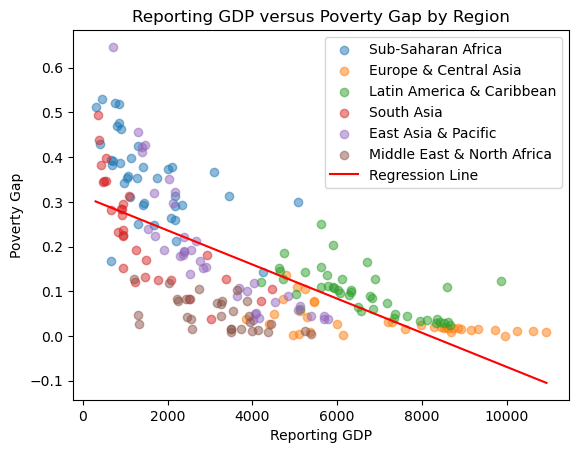

```python
# Prepare the data
X = np.concatenate([sub_saharan_data_yearly['reporting_gdp'],
                    europe_asia_data_yearly['reporting_gdp'],
                    latin_america_data_yearly['reporting_gdp'],
                    south_asia_data_yearly['reporting_gdp'],
                    east_asia_data_yearly['reporting_gdp'],
                    middle_north_data_yearly['reporting_gdp']])
y = np.concatenate([sub_saharan_data_yearly['poverty_gap'],
                    europe_asia_data_yearly['poverty_gap'],
                    latin_america_data_yearly['poverty_gap'],
                    south_asia_data_yearly['poverty_gap'],
                    east_asia_data_yearly['poverty_gap'],
                    middle_north_data_yearly['poverty_gap']])

# Made fit the linear regression model
regression_model = LinearRegression()
regression_model.fit(X.reshape(-1, 1), y)

# Slope and intercept
slope = regression_model.coef_[0]
intercept = regression_model.intercept_

print('Poverty VS GDP Results 6 Regions')
print("Slope:", slope)
print("Intercept:", intercept)

change_in_gdp = (1 / slope) * (-1)
print("Change in GDP required to decrease the poverty gap by 1%:", change_in_gdp)

# Scatter plot
plt.scatter(sub_saharan_data_yearly['reporting_gdp'], sub_saharan_data_yearly['poverty_gap'], alpha=0.5, label='Sub-Saharan Africa')
plt.scatter(europe_asia_data_yearly['reporting_gdp'], europe_asia_data_yearly['poverty_gap'], alpha=0.5, label='Europe & Central Asia')
plt.scatter(latin_america_data_yearly['reporting_gdp'], latin_america_data_yearly['poverty_gap'], alpha=0.5, label='Latin America & Caribbean')
plt.scatter(south_asia_data_yearly['reporting_gdp'], south_asia_data_yearly['poverty_gap'], alpha=0.5, label='South Asia')
plt.scatter(east_asia_data_yearly['reporting_gdp'], east_asia_data_yearly['poverty_gap'], alpha=0.5, label='East Asia & Pacific')
plt.scatter(middle_north_data_yearly['reporting_gdp'], middle_north_data_yearly['poverty_gap'], alpha=0.5, label='Middle East & North Africa')

# Regression line
x_values = np.linspace(np.min(X), np.max(X), 100)
y_values = slope * x_values + intercept
plt.plot(x_values, y_values, color='red', label='Regression Line')

# Labels and titles
plt.xlabel('Reporting GDP')
plt.ylabel('Poverty Gap')
plt.title('Reporting GDP versus Poverty Gap by Region')
plt.legend()

# Print graph
plt.show()
```

```python
# Calculate the residuals
y_pred = slope * X + intercept
residuals = y - y_pred

# Degrees of freedom
n = len(X)
df = n - 2

# Calculate the standard error of the slope
mse = np.mean(residuals**2)
std_error = np.sqrt(mse / np.sum((X - np.mean(X))**2))

# Calculate the t-value and p-value
t_value = slope / std_error
p_value = 2 * (1 - stats.t.cdf(abs(t_value), df))

# Print the t-value and p-value
print('T-value:', t_value)
print('P-value:', p_value)

# Significance level
alpha = 0.05

if p_value < alpha:
    print("Reject the null hypothesis")
else:
    print("Do not reject the null hypothesis")
```

```
T-value: -14.867199494842355
P-value: 0.0
Reject the null hypothesis
```

The hypothesis test results for the second regression model (with six regions) show a different slope coefficient and intercept than the previous model. We will still keep our same hypothesis:

Null Hypothesis: The is no relation between poverty gap and GDP. Alternative Hypothesis: There is a inverse relation between poverty gap and GDP.

The t-value for the slope coefficient is -14.867199494842355, and the p-value is 0.0. These results suggest that the slope coefficient is statistically significant, and we can reject the null hypothesis. Therefore, a meaningful relationship exists between GDP and the poverty gap in the six regions analyzed.

The t-value and p-value for the slope coefficient also differ from the previous. These differences are attributed to the exclusion of one region from the analysis, resulting in changes to the estimated relationship between GDP and the poverty gap.

### Plotting Only Latin America and Caribbean

Finally, to compare Latin America and the Caribbean, we need to compute a linear regression model of this region on its own. This will provide us with the necessary information to calculate elasticity and eventually draw conclusions.

```
Poverty VS GDP in Latin America and Caribbean
Slope: -2.3764824943591192e-05
Intercept: 0.2538140302992365
Change in GDP required to decrease the poverty gap by 1%: 42078.99710490719
```

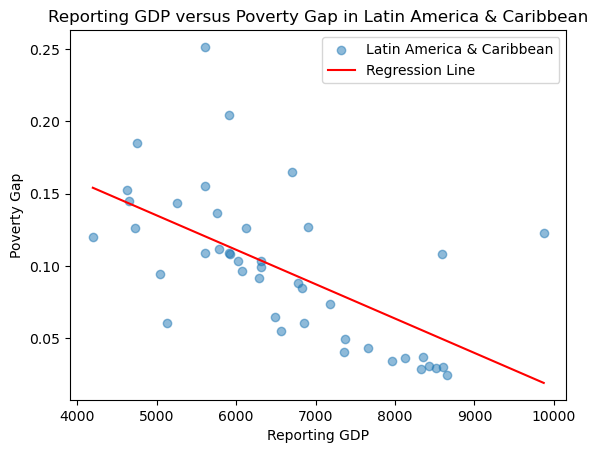

```python
# Get the data
X = latin_america_data_yearly['reporting_gdp'].values.reshape(-1, 1)
y = latin_america_data_yearly['poverty_gap'].values

# Fit a linear regression model
reg = LinearRegression()
reg.fit(X, y)

# slope and intercept
slope = reg.coef_[0]
intercept = reg.intercept_

print('Poverty VS GDP in Latin America and Caribbean')
print("Slope:", slope)
print("Intercept:", intercept)

change_in_gdp = (1 / slope) * (-1)
print("Change in GDP required to decrease the poverty gap by 1%:", change_in_gdp)

# Scatter plot
plt.scatter(latin_america_data_yearly['reporting_gdp'], latin_america_data_yearly['poverty_gap'], alpha=0.5, label='Latin America & Caribbean')

# Regression line
x_values = np.linspace(np.min(X), np.max(X), 100)
y_values = slope * x_values + intercept
plt.plot(x_values, y_values, color='red', label='Regression Line')

# Labels and titles
plt.xlabel('Reporting GDP')
plt.ylabel('Poverty Gap')
plt.title('Reporting GDP versus Poverty Gap in Latin America & Caribbean')
plt.legend()

# Plot
plt.show()
```

```python
# Calculate the residuals
y_pred = slope * X + intercept
residuals = y - y_pred

# Degrees of freedom
n = len(X)
df = n - 2

# Calculate the standard error of the slope
mse = np.mean(residuals**2)
std_error = np.sqrt(mse / np.sum((X - np.mean(X))**2))

# Calculate the t-value and p-value
t_value = slope / std_error
p_value = 2 * (1 - stats.t.cdf(abs(t_value), df))

# Print the t-value and p-value
print('T-value:', t_value)
print('P-value:', p_value)

# Significance level
alpha = 0.05

if p_value < alpha:
    print("Reject the null hypothesis")
else:
    print("Do not reject the null hypothesis")
```

```
T-value: -3.4422227906058245
P-value: 0.0013411679084747163
Reject the null hypothesis
```

Again:

Null Hypothesis: The is no relation between poverty gap and GDP. Alternative Hypothesis: There is a inverse relation between poverty gap and GDP.

The t-value for the slope coefficient is -3.4422227906058245, and the p-value is 0.0013411679084747163. These results suggest that the slope coefficient is statistically significant, and we can reject the null hypothesis. Therefore, a significant relationship exists between GDP and the poverty gap within the LAC region.

Comparing these results to the previous models, we observe variations in the slope coefficient, intercept, and hypothesis test results. These differences highlight the importance of examining the relationship between GDP and the poverty gap within specific regions or subsets of data. In addition, factors such as regional characteristics, economic conditions, and social dynamics within the LAC region may contribute to the observed differences in the regression coefficients and hypothesis test results.

As you can see, our calculations show that the change in GDP in Latin America and Caribbean is significantly higher than all the other regions combine, showing that LAC has other factors besides GDP that need to be taking into account in order to calculate poverty and predict future patterns accurately.

## Logarithmic Transformation and Elasticity Analysis of Poverty Gap and GDP

### Relationship in Latin America & Caribbean

In this section, we apply a natural logarithm transformation to the variables of GDP and the poverty gap within the Latin America & Caribbean (LAC) region. By taking the logarithm of the variables, we can explore the relationship between the logarithmic values of GDP and the logarithmic values of the poverty gap. Furthermore, the regression model with the transformed variables allows us to calculate the elasticity, representing the change in GDP concerning a 1% change in the poverty gap.

This elasticity value provides insights into the sensitivity of changes in GDP to poverty gaps. In addition, it helps understand the magnitude of economic growth's impact on reducing poverty in the region.

For this analysis we use the following resources: [Logarithmic Transformations and Elasticity](https://openstax.org/books/introductory-business-statistics/pages/13-5-interpretation-of-regression-coefficients-elasticity-and-logarithmic-transformation) [Elasticity Regression Analysis](https://www.sganalytics.com/blog/choosing-right-price-elasticity-model/)

```
-2.035180054636699
```

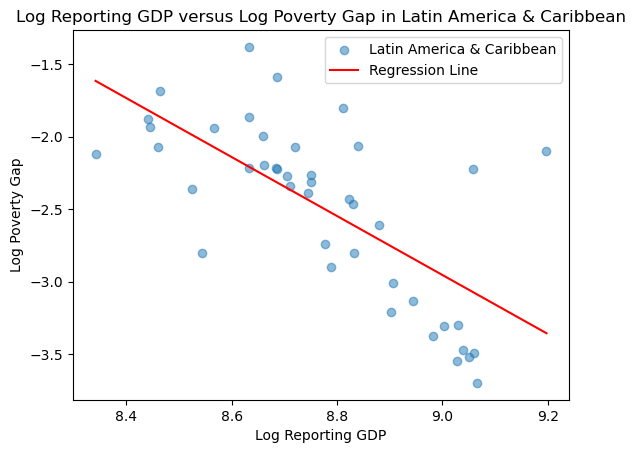

```python
# Apply natural logarithm transformation to the variables
X = np.log(latin_america_data_yearly['reporting_gdp']).values.reshape(-1, 1)
y = np.log(latin_america_data_yearly['poverty_gap']).values

# fit a linear regression model
reg = LinearRegression()
reg.fit(X, y)

# elasticity
elasticity = reg.coef_[0]
print(elasticity)

# Scatter plot
plt.scatter(np.log(latin_america_data_yearly['reporting_gdp']), np.log(latin_america_data_yearly['poverty_gap']), alpha=0.5, label='Latin America & Caribbean')

# Regression line
x_values = np.linspace(np.min(X), np.max(X), 100)
y_values = reg.intercept_ + elasticity * x_values
plt.plot(x_values, y_values, color='red', label='Regression Line')

# label and titles
plt.xlabel('Log Reporting GDP')
plt.ylabel('Log Poverty Gap')
plt.title('Log Reporting GDP versus Log Poverty Gap in Latin America & Caribbean')
plt.legend()

# show
plt.show()
```

This important discovery help us understand why Latin America and Caribbean have similar GDP to the ones in the other developing countries yet, when it comes to poverty it performs just as badly due to the way wealth is distributed.

To quickly illustrate this we will find two countries, one in Latin America and Caribbean and one in High Income Countries, that have a relatively similar GDP for the year 2019.

```python
# Filter the datasets for 2019 data
latin_america_2019 = latin_america_data[latin_america_data['reporting_year'] == 2019]
high_income_2019 = high_income_data[high_income_data['reporting_year'] == 2019]

# Calculate the difference in GDP between each pair of countries
min_diff = float('inf')
similar_countries = []

for latin_country in latin_america_2019['country_name']:
    latin_gdp = latin_america_2019.loc[latin_america_2019['country_name'] == latin_country, 'reporting_gdp'].values[0]

    for high_income_country in high_income_2019['country_name']:
        high_income_gdp = high_income_2019.loc[high_income_2019['country_name'] == high_income_country, 'reporting_gdp'].values[0]

        diff = abs(latin_gdp - high_income_gdp)

        if diff < min_diff:
            min_diff = diff
            similar_countries = [latin_country, high_income_country]

# Print the countries with similar GDP
latin_country, high_income_country = similar_countries
print(f"Latin America Country: {latin_country}")
print(f"High-Income Country: {high_income_country}")
```

```
Latin America Country: Uruguay
High-Income Country: Greece
```

When we graph a side by side comparison of the deciles that show wealth distribution, we can see a clear difference between those two countries. It might not seem fair to compare these two regions, but we can see the same phenomemom with regions that have similar performance.

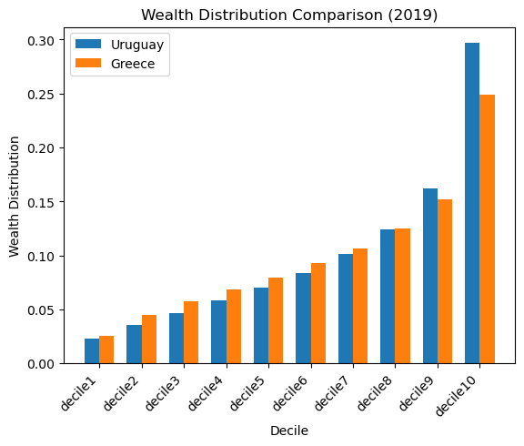

```python
# Filter data for year 2019 and select relevant columns
uruguay_2019 = data[(data['country_name'] == 'Uruguay') & (data['reporting_year'] == 2019)]
greece_2019 = data[(data['country_name'] == 'Greece') & (data['reporting_year'] == 2019)]

# Get the deciles for Uruguay and Greece
uruguay_deciles = uruguay_2019[['decile1', 'decile2', 'decile3', 'decile4', 'decile5', 'decile6', 'decile7', 'decile8', 'decile9', 'decile10']]
greece_deciles = greece_2019[['decile1', 'decile2', 'decile3', 'decile4', 'decile5', 'decile6', 'decile7', 'decile8', 'decile9', 'decile10']]

# Set the width of the bars
bar_width = 0.35

# Set the positions of the bars on the x-axis
x = np.arange(len(uruguay_deciles.columns))

# Create a figure and axis
fig, ax = plt.subplots()

# Create the bars for Uruguay
rects1 = ax.bar(x - bar_width/2, uruguay_deciles.values[0], bar_width, label='Uruguay')

# Create the bars for Greece
rects2 = ax.bar(x + bar_width/2, greece_deciles.values[0], bar_width, label='Greece')

# Add labels, title, and legend
ax.set_xlabel('Decile')
ax.set_ylabel('Wealth Distribution')
ax.set_title('Wealth Distribution Comparison (2019)')
plt.xticks(x, rotation=45, ha='right')
ax.set_xticklabels(uruguay_deciles.columns)
ax.legend()

# Show the plot
plt.show()
```

Now we will do the same comparison, but now with one in Latin America and Caribbean, and one in Europe and Central Asia that have a relatively similar GDP for the year 2019.

```python
# Filter the datasets for 2019 data
lac_2019 = latin_america_data[latin_america_data['reporting_year'] == 2019]
eca_2019 = europe_asia_data[europe_asia_data['reporting_year'] == 2019]

# Calculate the difference in GDP between each pair of countries
min_diff = float('inf')
similar_countries = []

for lac_country in lac_2019['country_name']:
    lac_gdp = lac_2019.loc[lac_2019['country_name'] == lac_country, 'reporting_gdp'].values[0]

    for eca_country in eca_2019['country_name']:
        eca_gdp = eca_2019.loc[eca_2019['country_name'] == eca_country, 'reporting_gdp'].values[0]

        diff = abs(lac_gdp - eca_gdp)

        if diff < min_diff:
            min_diff = diff
            similar_countries = [lac_country, eca_country]

# Print the countries with similar GDP
lac_country, eca_country = similar_countries
print(f"Latin America & Caribbean Country: {lac_country}")
print(f"Europe & Central Asia Country: {eca_country}")
```

```
Latin America & Caribbean Country: Peru
Europe & Central Asia Country: Serbia
```

As show in this plot, we can see that the wealth distribution is still very different for these two countries showing our hypothesis holds.

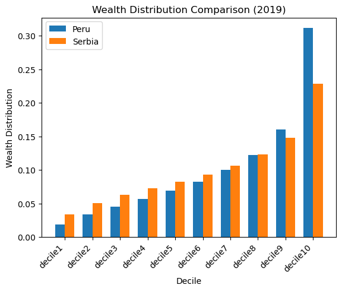

```python
# Filter data for year 2019 and select relevant columns
peru_2019 = data[(data['country_name'] == 'Peru') & (data['reporting_year'] == 2019)]
serbia_2019 = data[(data['country_name'] == 'Serbia') & (data['reporting_year'] == 2019)]

# Get the deciles for Peru and Serbia
peru_deciles = peru_2019[['decile1', 'decile2', 'decile3', 'decile4', 'decile5', 'decile6', 'decile7', 'decile8', 'decile9', 'decile10']]
serbia_deciles = serbia_2019[['decile1', 'decile2', 'decile3', 'decile4', 'decile5', 'decile6', 'decile7', 'decile8', 'decile9', 'decile10']]

# Set the width of the bars
bar_width = 0.35

# Set the positions of the bars on the x-axis
x = np.arange(len(peru_deciles.columns))

# Create a figure and axis
fig, ax = plt.subplots()

# Create the bars for Peru
rects1 = ax.bar(x - bar_width/2, peru_deciles.values[0], bar_width, label='Peru')

# Create the bars for Serbia
rects2 = ax.bar(x + bar_width/2, serbia_deciles.values[0], bar_width, label='Serbia')

# Add labels, title, and legend
ax.set_xlabel('Decile')
ax.set_ylabel('Wealth Distribution')
ax.set_title('Wealth Distribution Comparison (2019)')
plt.xticks(x, rotation=45, ha='right')
ax.set_xticklabels(peru_deciles.columns)
ax.legend()

# Show the plot
plt.show()
```

Latin America and Caribbean region faces a challenge that makes its condition unique to other countries. In order to accurate predict their poverty gap we have to take into consideration more than one factor in our regression model.

The provided graphing code generates a 3D surface plot to visualize the relationship between the poverty gap, GDP, and the Gini coefficient. We are extracts the independent variables (GDP and Gini coefficient) and the dependent variable (poverty gap). We want to express poverty_gap as:

$$\text{Poverty Gap} = \alpha + \beta0 \times \text{GDP} + \beta1 \times \text{Gini}$$

with alpha being intercept, and beta coefficient of GDP and coefficient of Gini respectively.

Next, a linear regression model is fitted to the data to obtain the coefficients and intercept. Data points and a 3D surface plot are generated based on the fitted model. The graph provides insights into the overall trend and patterns between the variables.

By modifying the angles of the 3D plot, different perspectives can be observed to gain a comprehensive understanding of the relationship between these variables.

For this regression model and 3D plotting we used the following resources:  
[Mutiple Linear Regression Model](https://datatofish.com/multiple-linear-regression-python/)  
[MPLOT3D Tutorials](https://matplotlib.org/stable/tutorials/toolkits/mplot3d.html)  
[Probability and Statistics for Engineering and the Science | 9th Edition](https://www.cengage.com/c/probability-and-statistics-for-engineering-and-the-sciences-9e-devore/9781305251809/)

```
Beta_0:
-4.25580832138683e-06
Beta_1:
0.25257712563166396
```

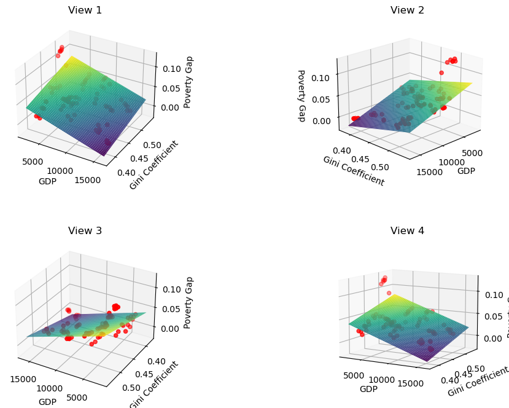

```python
import pandas as pd
import numpy as np
from sklearn.linear_model import LinearRegression
import matplotlib.pyplot as plt
from mpl_toolkits.mplot3d import Axes3D

# Filter the data for years 2014-2019
filtered_data = latin_america_data[(latin_america_data['reporting_year'] >= 2014) & (latin_america_data['reporting_year'] <= 2019)]

# Extracting variables
X = filtered_data[['reporting_gdp', 'gini']]
y = filtered_data['poverty_gap']

# fit a linear regression model
regression_model = LinearRegression()
regression_model.fit(X, y)

# Get the coefficients and intercept
beta_0 = regression_model.intercept_
beta_1, beta_2 = regression_model.coef_

print('Beta_0: ')
print(beta_1)
print('Beta_1: ')
print(beta_2)

# Generate data for plotting
gdp_range = np.linspace(np.min(X['reporting_gdp']), np.max(X['reporting_gdp']), 100)
gini_range = np.linspace(np.min(X['gini']), np.max(X['gini']), 100)
GDP, Gini_Coefficient = np.meshgrid(gdp_range, gini_range)
Poverty_Gap = beta_0 + beta_1 * GDP + beta_2 * Gini_Coefficient

# Create a figure with multiple subplots
fig = plt.figure(figsize=(12, 8))

# Plot the first 3D graph from the default angle
ax1 = fig.add_subplot(221, projection='3d')
ax1.plot_surface(GDP, Gini_Coefficient, Poverty_Gap, cmap='viridis')
ax1.set_xlabel('GDP')
ax1.set_ylabel('Gini Coefficient')
ax1.set_zlabel('Poverty Gap')
ax1.set_title('View 1')
ax1.scatter(X['reporting_gdp'], X['gini'], y, color='red', label='Data Points')

# Plot the second 3D graph from a different angle
ax2 = fig.add_subplot(222, projection='3d')
ax2.view_init(elev=20, azim=45)
ax2.plot_surface(GDP, Gini_Coefficient, Poverty_Gap, cmap='viridis')
ax2.set_xlabel('GDP')
ax2.set_ylabel('Gini Coefficient')
ax2.set_zlabel('Poverty Gap')
ax2.set_title('View 2')
ax2.scatter(X['reporting_gdp'], X['gini'], y, color='red', label='Data Points')

# Plot the third 3D graph from another angle
ax3 = fig.add_subplot(223, projection='3d')
ax3.view_init(elev=30, azim=120)
ax3.plot_surface(GDP, Gini_Coefficient, Poverty_Gap, cmap='viridis')
ax3.set_xlabel('GDP')
ax3.set_ylabel('Gini Coefficient')
ax3.set_zlabel('Poverty Gap')
ax3.set_title('View 3')
ax3.scatter(X['reporting_gdp'], X['gini'], y, color='red', label='Data Points')

# Plot the fourth 3D graph from a different angle
ax4 = fig.add_subplot(224, projection='3d')
ax4.view_init(elev=10, azim=-60)
ax4.plot_surface(GDP, Gini_Coefficient, Poverty_Gap, cmap='viridis')
ax4.set_xlabel('GDP')
ax4.set_ylabel('Gini Coefficient')
ax4.set_zlabel('Poverty Gap')
ax4.set_title('View 4')
ax4.scatter(X['reporting_gdp'], X['gini'], y, color='red', label='Data Points')

# Spacing
plt.subplots_adjust(hspace=0.4, wspace=0.3)

# print
plt.show()
```

Another way of interpreting this is by looking at beta_0 and beta_1 that should be opposite value, with beta_0 being negative and beta_1 being positive.

For the result we can conclude that each value had statistical significance, therefore implying a relation.

```python
import statsmodels.api as sm

# Add a constant column
X = sm.add_constant(X)

# Fit the linear regression model
regression_model = sm.OLS(y, X)
results = regression_model.fit()

# Coefficients
t_statistic = results.tvalues
p_values = results.pvalues

# significance level
alpha = 0.05

# Compare the p-values with the significance level
if p_values[0] < alpha:
    print("The intercept term is statistically significant.")
if p_values[1] < alpha:
    print("The coefficient for GDP is statistically significant.")
if p_values[2] < alpha:
    print("The coefficient for the Gini coefficient is statistically significant.")
```

```
The intercept term is statistically significant.
The coefficient for GDP is statistically significant.
The coefficient for the Gini coefficient is statistically significant.
```

# Insight and Final Conclusions

## Real Life Applications

1. Policy Strategies: Our findings suggest that focusing solely on increasing GDP may not effectively reduce poverty. Policymakers can use this insight to design more targeted strategies that address factors beyond GDP, such as inequality, wealth distribution, and social safety nets.
2. International Development Efforts: International development organizations like the United Nations, World Bank, and IDB can use this knowledge to inform their programs and initiatives. They can support countries in implementing policies and interventions that address wealth inequality, promote inclusive growth, and reduce poverty levels.
3. Poverty in Latin America: With an understanding of the relationship between GDP, wealth distribution, and poverty, Latin American countries should consider inequality more seriously when trying to find solutions regarding this issue since they are the most affected region.
4. Wealth Inequality: With the demonstrated patterns of inequality that exist in most Latin American countries, politicians and organizations should try to reduce the gap between deciles.